# Atividade 01: Análise de Participação em Atividades Extracurriculares

Igo da Costa Andrade

2024-09-05

## Contexto do Estudo de Caso

Imagine que você está analisando a participação dos alunos em atividades extracurriculares ao longo de um semestre. A universidade organizou uma série de workshops e eventos sobre “Desenvolvimento Pessoal e Profissional”, e você foi encarregado de analisar a eficácia dessas atividades.

A base de dados que você recebeu contém três variáveis:

- **Idade**: A faixa etária dos alunos que participaram.
- **Gênero**: O gênero dos participantes.
- **Quantidade**: O número de atividades em que os alunos de cada faixa etária e gênero participaram.

O objetivo da sua análise é entender o comportamento dos alunos em relação à participação nas atividades.

Você deve criar um gráfico que ajude a responder às seguintes perguntas:

1. Como a idade e o gênero influenciam a participação dos alunos nas atividades extracurriculares?
2. Há alguma tendência ou padrão que possa ser identificado nos dados?

Utilizando o pacote `ggplot2` , escolha uma visualização adequada para mostrar a relação entre idade, gênero e quantidade de participação.

Criar uma narrativa que comunique de forma clara e eficaz os principais insights extraídos dos dados.

## Resolução

### Bibliotecas necessárias

```r
# Dependências
library(tidyverse)
library(gt)
```

### Base de Dados

```r
# Base de Dados
dados <- data.frame(
  idade = c(18, 19, 20, 21, 22, 23, 18, 19, 20, 21, 22, 23),
  genero = c("Feminino", "Feminino", "Feminino", "Feminino","Feminino", "Feminino", "Masculino", "Masculino", "Masculino", "Masculino", "Masculino", "Masculino"),
  quantidade = c(16, 26, 21, 8,4, 2, 14, 25, 20, 15, 10, 8))
```

Visualização preliminar em formato tabular:

```r
# Tabela de Dados
dados |>
  gt() |>
  gt::tab_header(title = "Participação em Atividades Extracurriculares",
  subtitle = "Workshop sobre Desenvolvimento Pessoal e Profissional") |>
  gt::cols_label(idade = "Faixa Etária (anos)", genero = "Gênero", quantidade = "Número de Atividades")
```

Participação em Atividades Extracurriculares

Workshop sobre Desenvolvimento Pessoal e Profissional

| Faixa Etária (anos) | Gênero | Número de Atividades |
| --- | --- | --- |
| 18 | Feminino | 16 |
| 19 | Feminino | 26 |
| 20 | Feminino | 21 |
| 21 | Feminino | 8 |
| 22 | Feminino | 4 |
| 23 | Feminino | 2 |
| 18 | Masculino | 14 |
| 19 | Masculino | 25 |
| 20 | Masculino | 20 |
| 21 | Masculino | 15 |
| 22 | Masculino | 10 |
| 23 | Masculino | 8 |

### Criação do Gráfico para Análise

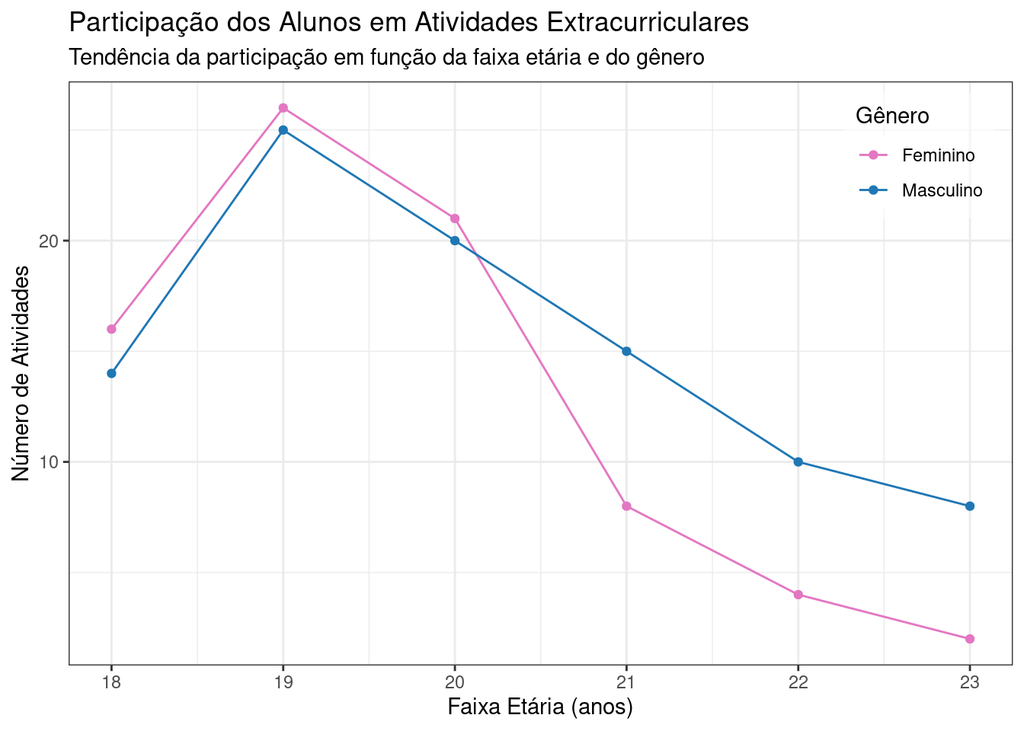

```r
# Gráfico
dados |>
  ggplot(aes(x=idade, y=quantidade, color=genero)) +
  geom_line() +
  geom_point() +
  scale_color_manual(values = c("Masculino" = "#1f77b4", "Feminino" = "#e377c2")) +
  labs(
    title = "Participação dos Alunos em Atividades Extracurriculares",
    subtitle = "Tendência da participação em função da faixa etária e do gênero",
    x = "Faixa Etária (anos)",
    y = "Número de Atividades",
    color = "Gênero"
  ) +
  theme_bw() +
  theme(
    legend.position = c(0.98, 0.98),
    legend.justification = c("right", "top"),
    legend.background = element_rect(fill = alpha("white", 0.5))
  )
```

## Análise da visualização gráfica

- Quanto ao impacto da **idade**, observa-se que os estudantes mais jovens (18 a 20 anos) têm uma participação maior em atividades do que os estudantes mais velhos. Entre os jovens, há um pico aos 19 anos. A partir dessa idade, há uma queda contínua na participação em atividades extracurriculares.
- O aspecto geral descrito acima ocorre para ambos os gêneros. Com relação ao fator **gênero**, as alunas mais jovens (18 a 20 anos) têm uma participação levemente superior à dos alunos na mesma faixa etária. Entretanto, a queda na participação a partir dos 20 anos é mais acentuada para as alunas do que para os alunos.
- A diminuição do engajamento típico em atividades extracurriculares, observada tanto para o gênero masculino quanto para o gênero feminino a partir dos 20 anos de idade, pode indicar que esses estudantes estão assumindo mais responsabilidades (trabalho, constituição de família ou aumento das dificuldades enfrentadas durante o curso).
- No caso das alunas, a queda mais brusca observada pode estar relacionada à maternidade e ao aumento das responsabilidades domésticas desempenhadas pelas mulheres no contexto da cultura brasileira. Essa carga adicional de trabalho doméstico, que muitas vezes é não remunerada e invisível, pode reduzir significativamente o tempo e a energia disponíveis para as alunas se dedicarem a atividades extracurriculares.
- Sugere-se:
  - Flexibilização de horários em que as disciplinas são ofertadas, bem como formas alternativas de participação nas atividades acadêmicas (como o ensino remoto);
  - Criação de espaços de inclusão para as mulheres com filhos, como salas de amamentação e creches para crianças pequenas dentro do campus universitário;
  - Programas de conscientização que:
    - incentivem a divisão equitativa das tarefas domésticas entre homens e mulheres;
    - orientem quanto à educação sexual e métodos contraceptivos;
    - promovam a organização social das mulheres para reivindicar serviços públicos e políticas orientadas à redução da carga de trabalho doméstico.